# STAT232 Final Project

```r
# Box test for lag=2
Box.test(modelfit$residuals, lag= 2, type="Ljung-Box")
```

```
##
##  Box-Ljung test
##
## data:  modelfit$residuals
## X-squared = 0.43617, df = 2, p-value = 0.8041
```

```r
Box.test(modelfit$residuals, type="Ljung-Box")
```

```
##
##  Box-Ljung test
##
## data:  modelfit$residuals
## X-squared = 0.0347, df = 1, p-value = 0.8522
```

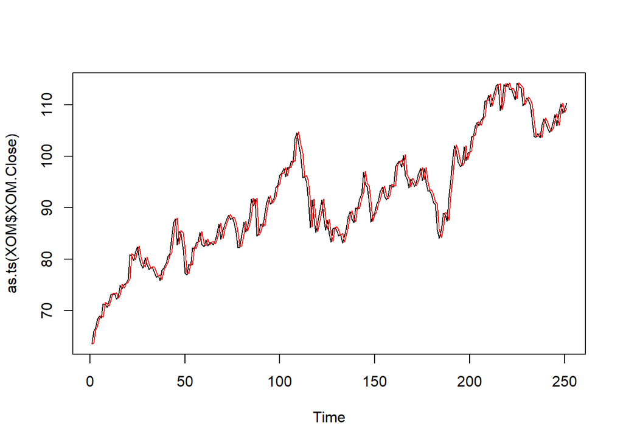

```r
plot(as.ts(XOM$XOM.Close))
lines(modelfit$fitted,col="red")
```

The Box-Ljung test for lag=2 yields a p-value of 0.8041, indicating no evidence of significant autocorrelation in the residuals at lag 2. Similarly, the test for lag=1 also shows no significant autocorrelation with a p-value of 0.8522. This suggests that the ARIMA model adequately captures the temporal dependencies in the data

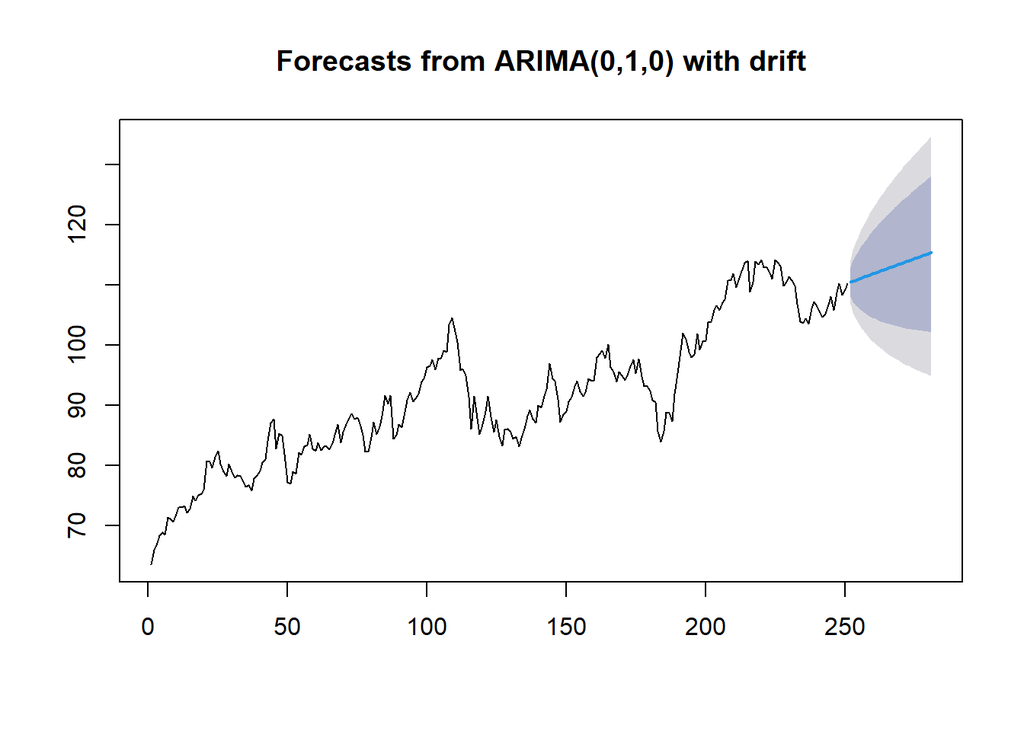

```r
plot(forecast(modelfit,h=30))
```

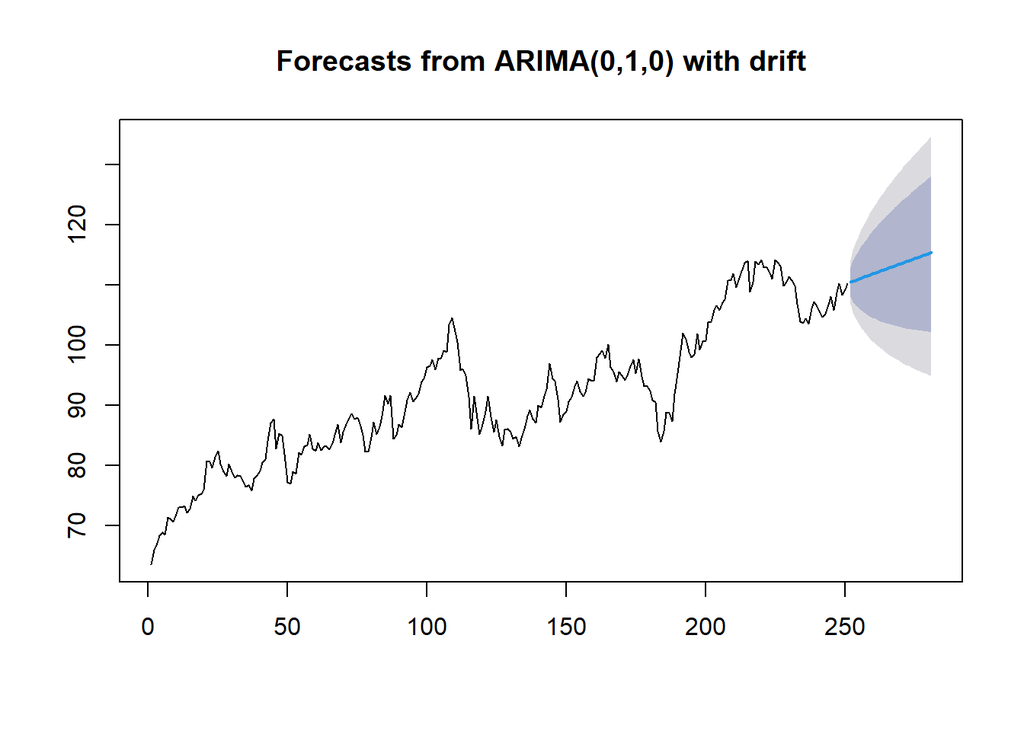

```r
price_forecast <- forecast(modelfit,h=30)
plot(price_forecast)
```

```r
head(price_forecast$mean)
```

```
## Time Series:
## Start = 252
## End = 257
## Frequency = 1
## [1] 110.4711 110.6421 110.8130 110.9838 111.1545 111.3251
```

```r
# Dividing the data into train & test sets , Applying the model
N = length (XOM$XOM.Close)
n = 0.8*N
train = XOM$XOM.Close[1:n, ]
test = XOM$XOM.Close[(n+1):N,]
trainarimafit <- auto.arima(train$XOM.Close ,lambda= "auto")
summary(trainarimafit)
```

```
## Series: train$XOM.Close
## ARIMA(0,1,0) with drift
## Box Cox transformation: lambda= -0.2413602
##
## Coefficients:
##       drift
##       8e-04
## s.e.  6e-04
##
## sigma^2 = 6.305e-05:  log likelihood = 680.51
## AIC=-1357.02   AICc=-1356.96   BIC=-1350.44
##
## Training set error measures:
##                       ME    RMSE      MAE         MPE     MAPE     MASE
## Training set -0.01737092 2.04917 1.599474 -0.02830457 1.826472 0.986718
##                    ACF1
## Training set 0.02470388
```

```r
predlen= length(test)
trainarima_fit <- forecast(trainarimafit, h= predlen)
```

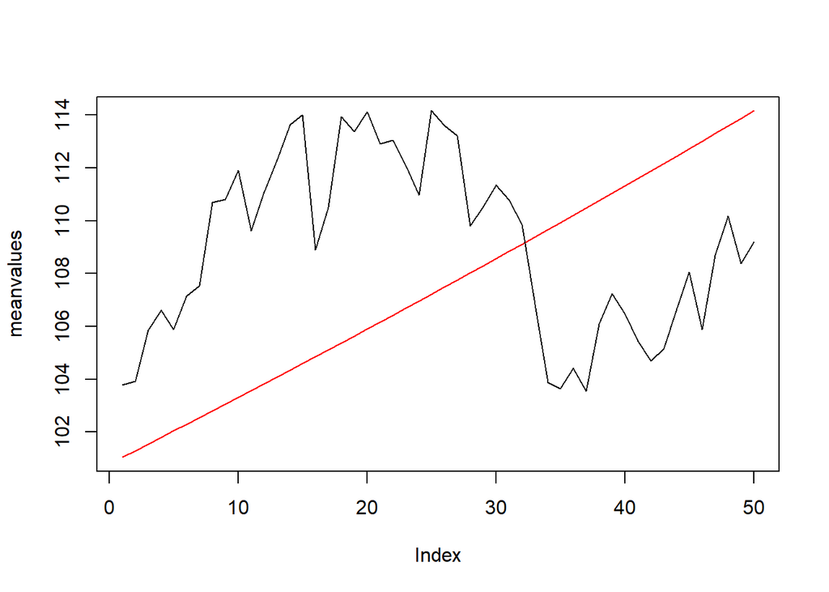

```r
#Plotting mean predicted  values vs real data
meanvalues<- as.vector(trainarima_fit$mean)
precios <- as.vector(test$XOM.Close)
plot(meanvalues, type = "l",col="red")
lines(precios, type = "l")
```

```r
#dev.off()
```

The red line, representing the mean predicted values, appears to follow a more linear trend, suggesting a relatively stable forecast over time. However, the black line, depicting the actual values from the test set, exhibits more variability, indicating fluctuations in the observed stock prices. This observation suggests that while the ARIMA model provides a general trend, it might not capture all the short-term fluctuations present in the actual data.

```r
#Fitting nnetar
 lambda = BoxCox.lambda(XOM$XOM.Close)
 dnn_fit = nnetar(XOM[,4],lambda=lambda)
 dnn_fit
```

```
## Series: XOM[, 4]
## Model:  NNAR(1,1)
## Call:   nnetar(y = XOM[, 4], lambda = lambda)
##
## Average of 20 networks, each of which is
## a 1-1-1 network with 4 weights
## options were - linear output units
##
## sigma^2 estimated as 102.6
```

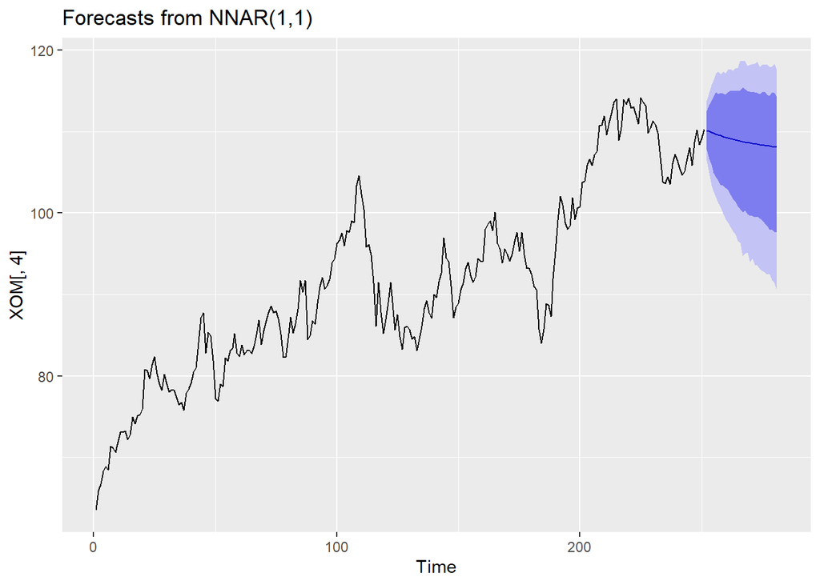

```r
 fcast = forecast(dnn_fit,PI=T,h=30)
 autoplot(fcast)
```

```r
 accuracy(dnn_fit)
```

```
##                        ME     RMSE      MAE         MPE     MAPE      MASE
## Training set -0.007807239 1.974758 1.550734 -0.05587799 1.703702 0.9813282
##                    ACF1
## Training set 0.01540301
```

**Accuracy:**

ME (Mean Error): The average prediction error is approximately -0.0079, suggesting that the model tends to slightly underestimate or overestimate actual close prices on average.

RMSE (Root Mean Square Error): With an RMSE value of about 1.9748, the model’s average prediction error is around this value, indicating the overall fit of the model to the data.

MAE (Mean Absolute Error): The MAE value of approximately 1.5509 represents the average absolute deviation of the predictions from the actual close prices, providing insight into the typical magnitude of errors.

MPE (Mean Percentage Error): The MPE of around -0.0562% indicates a slight negative bias in the predictions, suggesting that, on average, the model underestimates actual close prices.

MAPE (Mean Absolute Percentage Error): The MAPE value of about 1.7039% represents the average percentage deviation of the predictions from the actual values, providing a relative measure of the model’s accuracy.

MASE (Mean Absolute Scaled Error): With a value close to 1 (approximately 0.9814), the MASE indicates that the NNAR model performs similarly to a naive benchmark model, such as a random walk.

ACF1 (Autocorrelation Function at Lag 1): The ACF1 value of 0.0155 assesses the correlation of the model residuals at lag 1, indicating any remaining autocorrelation in the errors after accounting for the lag-1 autocorrelation.

**Overall Interpretation:**

Overall, the NNAR model applied to XOM stock close prices demonstrates relatively good performance in terms of accuracy measures. While there is a slight bias in the predictions, indicated by the negative MPE, the overall magnitude of errors, as reflected by RMSE and MAE, is reasonable. Additionally, the model’s performance, as measured by MASE, suggests that it performs comparably to a simple benchmark model.

# Industry Comparision

We analyzed the Technology and Energy index prices, compared their charts, and found a correlation between their closing prices.

```r
getSymbols("XLK",src="yahoo",from="2022-01-01",to = "2022-12-31")
```

```
## [1] "XLK"
```

```r
head(XLK)
```

```
##            XLK.Open XLK.High XLK.Low XLK.Close XLK.Volume XLK.Adjusted
## 2022-01-03   174.10   175.68  173.34    175.52   10151400     172.0342
## 2022-01-04   175.82   176.00  172.35    173.66    8324000     170.2112
## 2022-01-05   172.65   172.78  168.26    168.32   11814200     164.9772
## 2022-01-06   166.98   169.20  166.47    167.47   11883600     164.1441
## 2022-01-07   167.36   168.16  164.84    165.93   15244300     162.6347
## 2022-01-10   163.46   166.17  161.29    165.96   16250700     162.6641
```

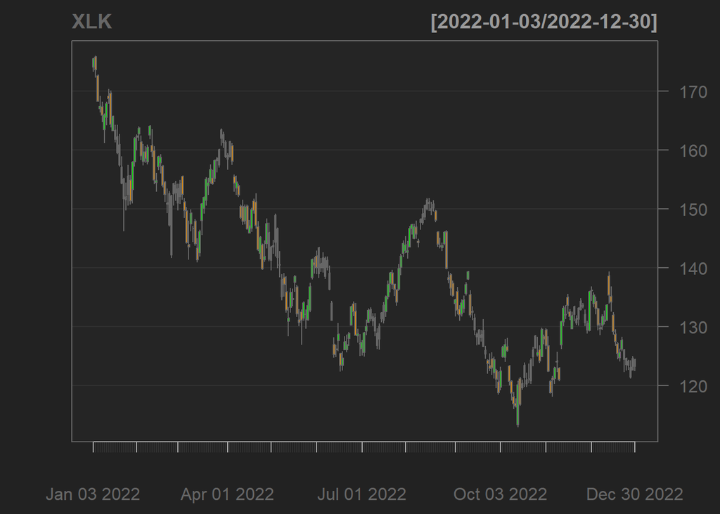

```r
chartSeries(XLK,TA = NULL)
```

```r
getSymbols("XLE",src="yahoo",from="2022-01-01",to = "2022-12-31")
```

```
## [1] "XLE"
```

```r
head(XLE)
```

```
##            XLE.Open XLE.High XLE.Low XLE.Close XLE.Volume XLE.Adjusted
## 2022-01-03    55.58    57.31   55.55     57.22   32527100     52.51132
## 2022-01-04    58.00    59.43   57.81     59.20   39978800     54.32839
## 2022-01-05    59.78    60.44   59.10     59.19   45402000     54.31921
## 2022-01-06    60.58    60.85   59.66     60.51   37340700     55.53058
## 2022-01-07    60.74    61.50   60.32     61.34   35584600     56.29228
## 2022-01-10    61.48    61.60   60.35     61.15   33236500     56.11792
```

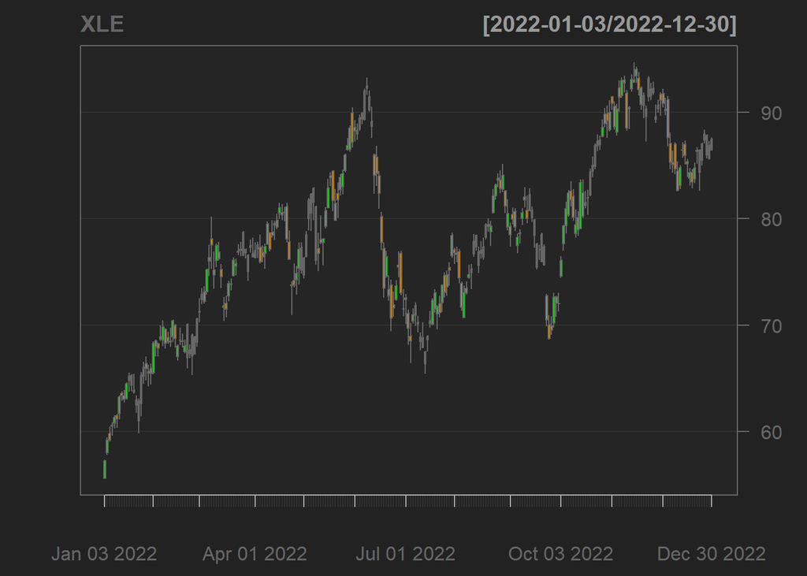

```r
chartSeries(XLE,TA = NULL)
```

```r
str(XLK)
```

```
## An xts object on 2022-01-03 / 2022-12-30 containing:
##   Data:    double [251, 6]
##   Columns: XLK.Open, XLK.High, XLK.Low, XLK.Close, XLK.Volume ... with 1 more column
##   Index:   Date [251] (TZ: "UTC")
##   xts Attributes:
##     $ src    : chr "yahoo"
##     $ updated: POSIXct[1:1], format: "2024-03-22 03:29:01"
```

```r
# Combine closing prices of index into a single DataFrame
all_index_closing_prices <- data.frame(XLK = XLK$XLK.Adjusted, XLE = XLE$XLE.Adjusted)

# Check the structure of the DataFrame
str(all_index_closing_prices)
```

```
## 'data.frame':    251 obs. of  2 variables:
##  $ XLK.Adjusted: num  172 170 165 164 163 ...
##  $ XLE.Adjusted: num  52.5 54.3 54.3 55.5 56.3 ...
```

```r
# Compute correlation matrix of closing prices
correlation_matrix_indexes <- cor(all_index_closing_prices)  # Exclude Date column

# Print correlation matrix
print(correlation_matrix_indexes)
```

```
##              XLK.Adjusted XLE.Adjusted
## XLK.Adjusted    1.0000000   -0.6227246
## XLE.Adjusted   -0.6227246    1.0000000
```

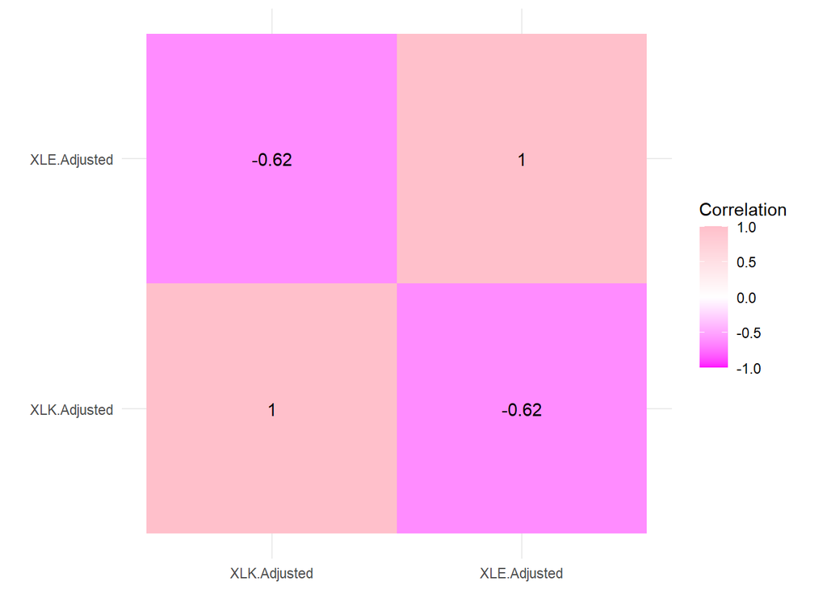

```r
correlation_df_indexes <- reshape2::melt(correlation_matrix_indexes)
# Plot heatmap with correlation numbers
ggplot(data = correlation_df_indexes, aes(x = Var1, y = Var2, fill = value, label = round(value, 2))) +
  geom_tile() +
  geom_text() +
  scale_fill_gradient2(low = "magenta", mid = "white", high = "pink", midpoint = 0, limit = c(-1,1), space = "Lab", name="Correlation") +
  theme_minimal() +
  theme(axis.title = element_blank(),
        legend.position = "right") +
  coord_fixed()
```

# Conclusion:

Based on the analysis of various charts and data for Apple (AAPL), Microsoft (MSFT), Exxon Mobil (XOM), and NextEra Energy (NEE) over a one-year period, here are the key takeaways:

**Risk-Return Tradeoff:**

- The expected return vs risk chart indicated a positive relationship. Apple and Microsoft, positioned in the upper right quadrant, had potentially higher expected returns but also higher risk, reflecting the technology sector’s characteristics.
- Exxon Mobil and NextEra Energy plotted in the lower left quadrant, suggesting potentially lower expected returns but also lower risk, which may be suitable for investors seeking less volatility. **Limitations:**
- The data covered a one-year period, and correlations can change over time. This analysis provides a snapshot but may not capture long-term trends.
- Stock prices are influenced by various factors beyond historical data or correlations.

Overall, this analysis highlights the importance of considering both risk and return when making investment decisions. The technology sector may offer higher potential returns but also comes with greater risk, while utility and energy sectors might provide lower risk but potentially lower returns as well. Diversifying your portfolio across sectors can be a strategy to manage risk.